# Homework 2 - DS2 - Neural Nets

Cosmin Catalin Ticu

4/4/2021

### The original R-codes for this task can be found in the R script of this [GitHub repo](https://github.com/cosmin-ticu/DS2-neural-nets).

# 1. Fashion MNIST data

## a. Show some example images from the data.

Taking a look at the first 6 images in the MNIST fashion dataset.

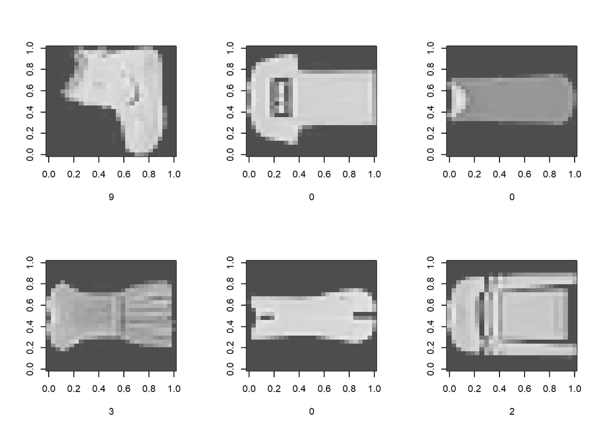

```r
# Task 1 ------------------------------------------------------------------

# import data
fashion_mnist <- dataset_fashion_mnist()
x_train <- fashion_mnist$train$x
y_train <- fashion_mnist$train$y
x_test <- fashion_mnist$test$x
y_test <- fashion_mnist$test$y

# a, Show some example images from the data.

# split the canvas into rows and columns
par(mfrow = c(2, 3))

# plot the first 6 images
for (i in 1:6){
  image(
    x_train[i,,],
    col = gray.colors(255), xlab = y_train[i], ylab = ""
  )
}
```

The train dataset contains 60,000 grayscale images of fashion items while the test contains 10,000 grayscale images. The items belong to 10 classes which are indicated by numbers ranging from 0 to 9 and can be found in the y-variable vectors. The data without the label is stored in three dimensional arrays. Writing below each picture indicates the true class.

## b. Train a fully connected deep network to predict items.

Normalizing the data after creating a validation set as well. The provided data only came with training and test sets.

```r
# b, Train a fully connected deep network to predict items.

# split train data into train and validation sets
# get indexes
set.seed(1234)
train_indices <- sample(seq(nrow(x_train)), 10000)

# split x
data_train_x <- x_train[train_indices,, ]
data_valid_x <- x_train[-train_indices,, ]

# split y
data_train_y <- y_train[train_indices]
data_valid_y <- y_train[-train_indices]

# rescale x - data normalization
data_train_x <- as.matrix(as.data.frame.array(data_train_x)) / 255
data_valid_x <- as.matrix(as.data.frame.array(data_valid_x)) / 255
data_test_x <- as.matrix(as.data.frame.array(x_test)) / 255

# one-hot encoding for y
data_train_y <- to_categorical(data_train_y, 10)
data_valid_y <- to_categorical(data_valid_y, 10)
data_test_y <- to_categorical(y_test, 10)
```

The following model building process contains the codes used in creating the models as snippets and summary tables for each model which show the total number of parameters and the specifications of each hidden layer. Plots of the training history of the models are also made after each model. The input and output layers do not change as there are always 784 inputs (28 by 28 images) and 10 outputs as per the 10 classification classes.

Building the baseline model following Janos’ example from class.

```r
### BASELINE MODEL
# create model object - baseline Janos
model_janos <- keras_model_sequential()

# add layers to the model
model_janos %>%
  layer_dense(units = 128, activation = 'relu', input_shape = c(784)) %>% # 784 pixels
  layer_dropout(rate = 0.3) %>% # we leave 30% of the node weights unchanged
  layer_dense(units = 10, activation = 'softmax') # 10 nodes because of the 10 digits

# check model summary
summary(model_janos)
```

```
## Model: "sequential"
## ________________________________________________________________________________
## Layer (type)                        Output Shape                    Param #
## ================================================================================
## dense_1 (Dense)                     (None, 128)                     100480
## ________________________________________________________________________________
## dropout (Dropout)                   (None, 128)                     0
## ________________________________________________________________________________
## dense (Dense)                       (None, 10)                      1290
## ================================================================================
## Total params: 101,770
## Trainable params: 101,770
## Non-trainable params: 0
## ________________________________________________________________________________
```

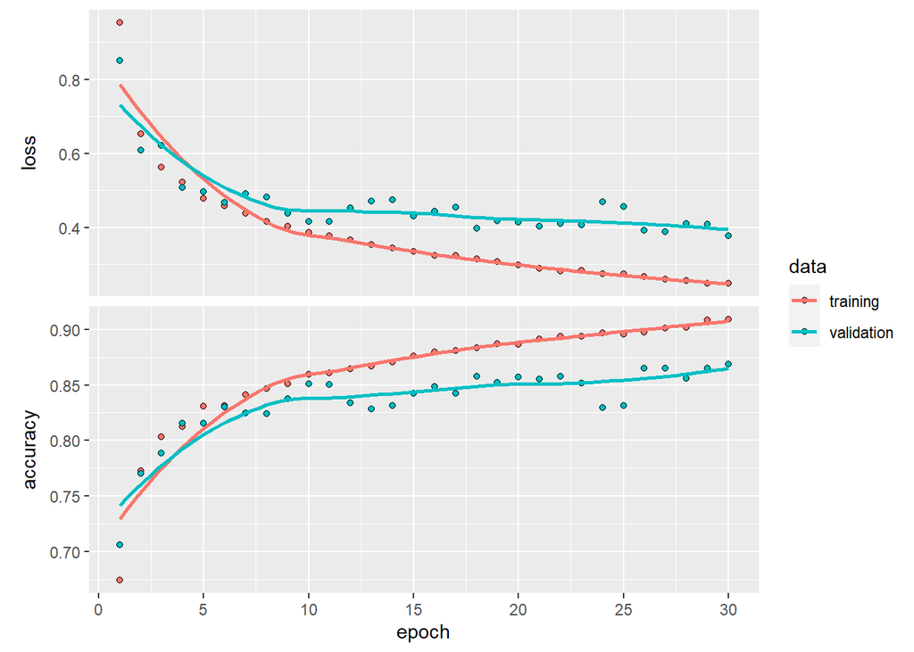

```r
# set loss function and the metrics we want to see
compile(
  model_janos,
  loss = 'categorical_crossentropy',
  optimizer = optimizer_rmsprop(),
  metrics = c('accuracy')
)

# fit model
# set.seed(1234)
# janosRDS_NN <- fit(
#   model_janos, data_train_x, data_train_y,
#   epochs = 30, batch_size = 128,
#   validation_data = list(data_valid_x, data_valid_y)
# )

# saveRDS(janosRDS_NN, file = "data/janosRDS_NN.rds")
janosRDS_NN <- readRDS(file = "F:/OneDrive - Central European University/Courses/Winter_Term/Data Science 2/assignment 2/DS2-neural-nets/data/janosRDS_NN.rds")

# Save the model
# save_model_hdf5(model_janos, "data/model_janos.h5")

# Recreate the exact same model purely from the file
model_janos <- load_model_hdf5("F:/OneDrive - Central European University/Courses/Winter_Term/Data Science 2/assignment 2/DS2-neural-nets/data/model_janos.h5")

# evaluate model
model_janos_eval <- as.data.frame(evaluate(model_janos, data_valid_x, data_valid_y))

plot(janosRDS_NN)
```

Building a much simpler model than the benchmark, without a dropout layer.

```r
### FIRST MODEL
# create model object
model1 <- keras_model_sequential()

# add layers to the model
model1 %>%
  layer_dense(units = 28, activation = 'relu', input_shape = c(784)) %>% # 784 pixels
  layer_dense(units = 10, activation = 'softmax') # 10 nodes because of the 10 digits

# check model summary
summary(model1)
```

```
## Model: "sequential_1"
## ________________________________________________________________________________
## Layer (type)                        Output Shape                    Param #
## ================================================================================
## dense_3 (Dense)                     (None, 28)                      21980
## ________________________________________________________________________________
## dense_2 (Dense)                     (None, 10)                      290
## ================================================================================
## Total params: 22,270
## Trainable params: 22,270
## Non-trainable params: 0
## ________________________________________________________________________________
```

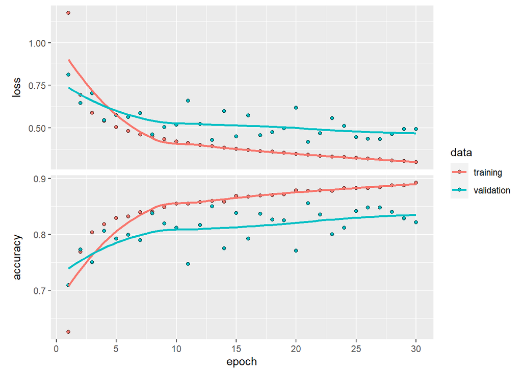

```r
# set loss function and the metrics we want to see
compile(
  model1,
  loss = 'categorical_crossentropy',
  optimizer = optimizer_rmsprop(),
  metrics = c('accuracy')
)

# fit model
# set.seed(1234)
# model1RDS_NN <- fit(
#   model1, data_train_x, data_train_y,
#   epochs = 30, batch_size = 128,
#   validation_data = list(data_valid_x, data_valid_y)
# )

# saveRDS(model1RDS_NN, file = "data/model1RDS_NN.rds")
model1RDS_NN <- readRDS(file = "F:/OneDrive - Central European University/Courses/Winter_Term/Data Science 2/assignment 2/DS2-neural-nets/data/model1RDS_NN.rds")

# Save the model
# save_model_hdf5(model1, "data/model1.h5")

# Recreate the exact same model purely from the file
model1 <- load_model_hdf5("F:/OneDrive - Central European University/Courses/Winter_Term/Data Science 2/assignment 2/DS2-neural-nets/data/model1.h5")

# evaluate model
model1_eval <- as.data.frame(evaluate(model1, data_valid_x, data_valid_y))

plot(model1RDS_NN)
```

Building the second model with another fully connected hidden layer between the relu and the output layers of the first model.

```r
### SECOND MODEL
# create model object
model2 <- keras_model_sequential()

# add layers to the model
model2 %>%
  layer_dense(units = 28, activation = 'relu', input_shape = c(784)) %>% # 784 pixels
  layer_dense(units = 28, activation = 'sigmoid') %>%
  layer_dense(units = 10, activation = 'softmax') # 10 nodes because of the 10 digits

# check model summary
summary(model2)
```

```
## Model: "sequential_2"
## ________________________________________________________________________________
## Layer (type)                        Output Shape                    Param #
## ================================================================================
## dense_6 (Dense)                     (None, 28)                      21980
## ________________________________________________________________________________
## dense_5 (Dense)                     (None, 28)                      812
## ________________________________________________________________________________
## dense_4 (Dense)                     (None, 10)                      290
## ================================================================================
## Total params: 23,082
## Trainable params: 23,082
## Non-trainable params: 0
## ________________________________________________________________________________
```

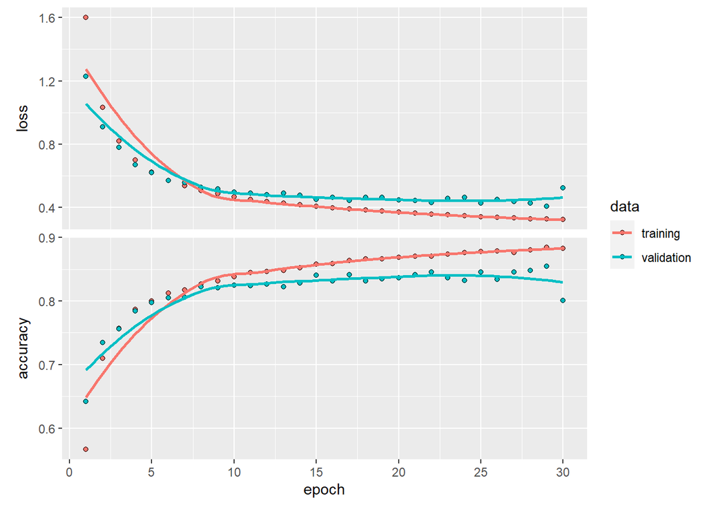

```r
# set loss function and the metrics we want to see
compile(
  model2,
  loss = 'categorical_crossentropy',
  optimizer = optimizer_rmsprop(),
  metrics = c('accuracy')
)

# fit model
# set.seed(1234)
# model2RDS_NN <- fit(
#   model2, data_train_x, data_train_y,
#   epochs = 30, batch_size = 128,
#   validation_data = list(data_valid_x, data_valid_y)
# )

# saveRDS(model2RDS_NN, file = "data/model2RDS_NN.rds")
model2RDS_NN <- readRDS(file = "F:/OneDrive - Central European University/Courses/Winter_Term/Data Science 2/assignment 2/DS2-neural-nets/data/model2RDS_NN.rds")

# evaluate model
model2_eval <- as.data.frame(evaluate(model2, data_valid_x, data_valid_y))

# Save the model
# save_model_hdf5(model2, "data/model2.h5")

# Recreate the exact same model purely from the file
model2 <- load_model_hdf5("F:/OneDrive - Central European University/Courses/Winter_Term/Data Science 2/assignment 2/DS2-neural-nets/data/model2.h5")

plot(model2RDS_NN)
```

Increasing the model complexity by including a drop-out layer and yet another dense layer with a tangential function.

```r
### THIRD MODEL - TOO COMPLEX --> OVERFIT
# create model object
model3 <- keras_model_sequential()

# add layers to the model
model3 %>%
  layer_dense(units = 100, activation = 'relu', input_shape = c(784)) %>% # 784 pixels
  layer_dense(units = 100, activation = 'sigmoid') %>%
  layer_dense(units = 100, activation = 'tanh') %>% # tangential function
  layer_dropout(rate = 0.3) %>% # we leave 30% of the node weights unchanged
  layer_dense(units = 10, activation = 'softmax') # 10 nodes because of the 10 digits

# check model summary
summary(model3)
```

```
## Model: "sequential_3"
## ________________________________________________________________________________
## Layer (type)                        Output Shape                    Param #
## ================================================================================
## dense_10 (Dense)                    (None, 100)                     78500
## ________________________________________________________________________________
## dense_9 (Dense)                     (None, 100)                     10100
## ________________________________________________________________________________
## dense_8 (Dense)                     (None, 100)                     10100
## ________________________________________________________________________________
## dropout_1 (Dropout)                 (None, 100)                     0
## ________________________________________________________________________________
## dense_7 (Dense)                     (None, 10)                      1010
## ================================================================================
## Total params: 99,710
## Trainable params: 99,710
## Non-trainable params: 0
## ________________________________________________________________________________
```

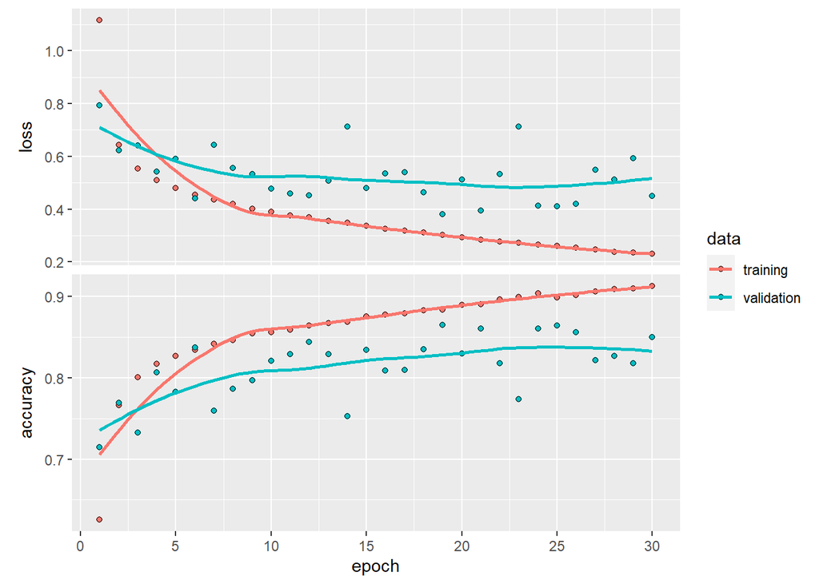

```r
# set loss function and the metrics we want to see
compile(
  model3,
  loss = 'categorical_crossentropy',
  optimizer = optimizer_rmsprop(),
  metrics = c('accuracy')
)

# fit model
# set.seed(1234)
# model3RDS_NN <- fit(
#   model3, data_train_x, data_train_y,
#   epochs = 30, batch_size = 128,
#   validation_data = list(data_valid_x, data_valid_y)
# )

# saveRDS(model3RDS_NN, file = "data/model3RDS_NN.rds")
model3RDS_NN <- readRDS(file = "F:/OneDrive - Central European University/Courses/Winter_Term/Data Science 2/assignment 2/DS2-neural-nets/data/model3RDS_NN.rds")

# Save the model
# save_model_hdf5(model3, "data/model3.h5")

# Recreate the exact same model purely from the file
model3 <- load_model_hdf5("F:/OneDrive - Central European University/Courses/Winter_Term/Data Science 2/assignment 2/DS2-neural-nets/data/model3.h5")

# evaluate model
model3_eval <- as.data.frame(evaluate(model3, data_valid_x, data_valid_y))

plot(model3RDS_NN)
```

The fourth model forfeits one of the dense layers and drastically increases the weight of the drop-out layer in order to ensure the model does not appear overfitted, like its previous counterpart.

```r
### FOURTH MODEL
# create model object
model4 <- keras_model_sequential()

# add layers to the model
model4 %>%
  layer_dense(units = 100, activation = 'sigmoid', input_shape = c(784)) %>%
  layer_dense(units = 100, activation = 'tanh') %>% # tangential function
  layer_dropout(rate = 0.7) %>% # increase dropout rate to 70%
  layer_dense(units = 10, activation = 'softmax') # 10 nodes because of the 10 digits

# check model summary
summary(model4)
```

```
## Model: "sequential_4"
## ________________________________________________________________________________
## Layer (type)                        Output Shape                    Param #
## ================================================================================
## dense_13 (Dense)                    (None, 100)                     78500
## ________________________________________________________________________________
## dense_12 (Dense)                    (None, 100)                     10100
## ________________________________________________________________________________
## dropout_2 (Dropout)                 (None, 100)                     0
## ________________________________________________________________________________
## dense_11 (Dense)                    (None, 10)                      1010
## ================================================================================
## Total params: 89,610
## Trainable params: 89,610
## Non-trainable params: 0
## ________________________________________________________________________________
```

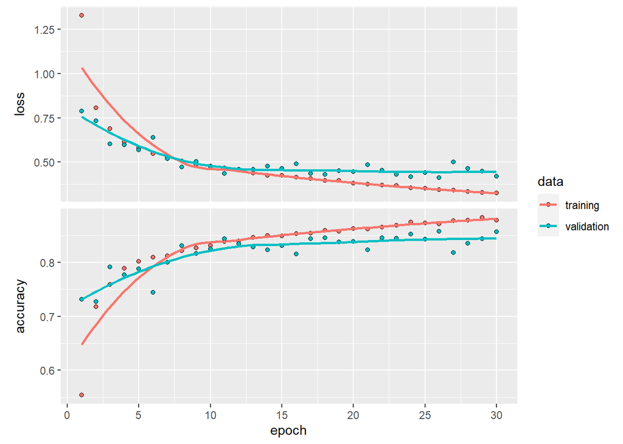

```r
# set loss function and the metrics we want to see
compile(
  model4,
  loss = 'categorical_crossentropy',
  optimizer = optimizer_rmsprop(),
  metrics = c('accuracy')
)

# fit model
# set.seed(1234)
# model4RDS_NN <- fit(
#   model4, data_train_x, data_train_y,
#   epochs = 30, batch_size = 128,
#   validation_data = list(data_valid_x, data_valid_y)
# )
#
# saveRDS(model4RDS_NN, file = "data/model4RDS_NN.rds")
model4RDS_NN <- readRDS(file = "F:/OneDrive - Central European University/Courses/Winter_Term/Data Science 2/assignment 2/DS2-neural-nets/data/model4RDS_NN.rds")

# Save the model
# save_model_hdf5(model4, "data/model4.h5")

# Recreate the exact same model purely from the file
model4 <- load_model_hdf5("F:/OneDrive - Central European University/Courses/Winter_Term/Data Science 2/assignment 2/DS2-neural-nets/data/model4.h5")

# evaluate model
model4_eval <- as.data.frame(evaluate(model4, data_valid_x, data_valid_y))

plot(model4RDS_NN)
```

The fifth model employs a softplus initial input layer, moving away from the linearity associated with the relu activation function. Normally the softplus activitation function is made so that negative values do not all achieve a zero value (like in the relu activation function). The drop-out rate of the respective layer was also made very small.

```r
### FIFTH MODEL --> signs of overfitting
# create model object
model5 <- keras_model_sequential()

# add layers to the model
model5 %>%
  layer_dense(units = 100, activation = 'softplus', input_shape = c(784)) %>% # not really necessary because inputs are not negative
  layer_dense(units = 100, activation = 'relu') %>% # standard bent linear model
  layer_dropout(rate = 0.01) %>% # change to 1% drop-out rate
  layer_dense(units = 10, activation = 'softmax') # 10 nodes because of the 10 digits

# check model summary
summary(model5)
```

```
## Model: "sequential_5"
## ________________________________________________________________________________
## Layer (type)                        Output Shape                    Param #
## ================================================================================
## dense_16 (Dense)                    (None, 100)                     78500
## ________________________________________________________________________________
## dense_15 (Dense)                    (None, 100)                     10100
## ________________________________________________________________________________
## dropout_3 (Dropout)                 (None, 100)                     0
## ________________________________________________________________________________
## dense_14 (Dense)                    (None, 10)                      1010
## ================================================================================
## Total params: 89,610
## Trainable params: 89,610
## Non-trainable params: 0
## ________________________________________________________________________________
```

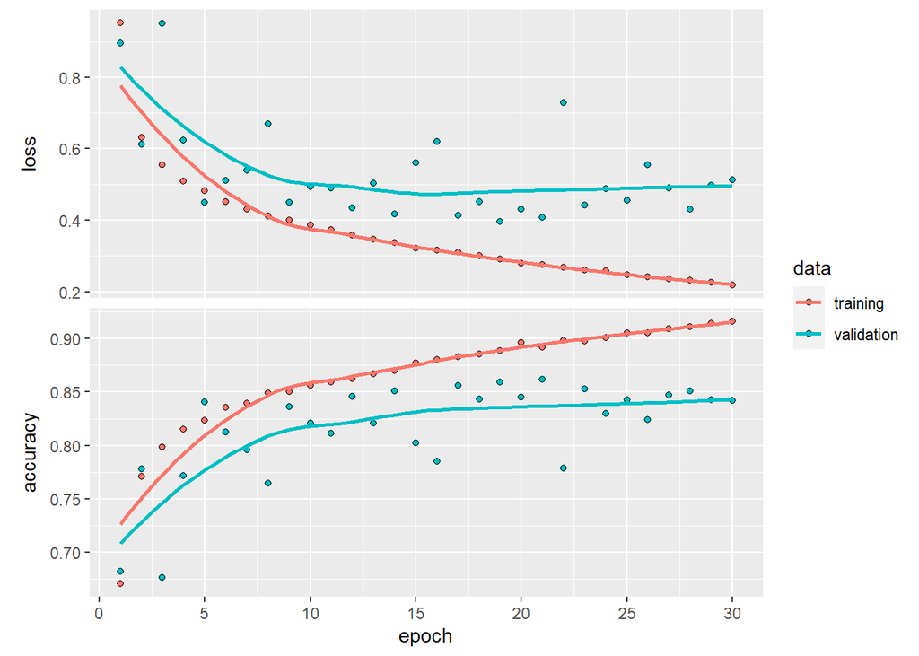

```r
# set loss function and the metrics we want to see
compile(
  model5,
  loss = 'categorical_crossentropy',
  optimizer = optimizer_rmsprop(),
  metrics = c('accuracy')
)

# fit model
# set.seed(1234)
# model5RDS_NN <- fit(
#   model5, data_train_x, data_train_y,
#   epochs = 30, batch_size = 128,
#   validation_data = list(data_valid_x, data_valid_y)
# )
#
# saveRDS(model5RDS_NN, file = "data/model5RDS_NN.rds")
model5RDS_NN <- readRDS(file = "F:/OneDrive - Central European University/Courses/Winter_Term/Data Science 2/assignment 2/DS2-neural-nets/data/model5RDS_NN.rds")

# Save the model
# save_model_hdf5(model5, "data/model5.h5")

# Recreate the exact same model purely from the file
model5 <- load_model_hdf5("F:/OneDrive - Central European University/Courses/Winter_Term/Data Science 2/assignment 2/DS2-neural-nets/data/model5.h5")

# evaluate model
model5_eval <- as.data.frame(evaluate(model5, data_valid_x, data_valid_y))

plot(model5RDS_NN)
```

```r
# build model comparison table for all 3 dataset partitions
model5_eval_test <- as.data.frame(evaluate(model5, data_test_x, data_test_y))

final_model_comparison <- cbind(as.data.frame(evaluate(model5, data_train_x, data_train_y)) ,model5_eval, model5_eval_test)
```

Making a model comparison table of the crossentropy loss function values and the accuracy, we get the following results.

```r
# model comparison
model_comparison <- cbind(model_janos_eval, model1_eval, model2_eval, model3_eval, model4_eval, model5_eval)

colnames(model_comparison) <- c('baseline', 'model1', 'model2', 'model3', 'model4', 'model5')

knitr::kable(model_comparison, caption = 'NN model comparison', digits = 2) %>%
  kable_styling( position = "center", latex_options = 'hold_position', bootstrap_options = c("striped", "hover"))
```

NN model comparison

|  | baseline | model1 | model2 | model3 | model4 | model5 |
| --- | --- | --- | --- | --- | --- | --- |
| loss | 0.38 | 0.49 | 2.44 | 0.45 | 0.42 | 0.51 |
| accuracy | 0.87 | 0.82 | 0.10 | 0.85 | 0.86 | 0.84 |

## c. Evaluate the model on the test set. How does test error compare to validation error?

Looking at model 5’s performance on all 3 of the datasets (training, validation and test), we can expect that test performance will be lower as it has fewer observations than validation. Accuracy goes down a little, however loss is more noticeable due to smaller test dataset.

```r
# c, Evaluate the model on the test set. How does test error compare to validation error?

names(final_model_comparison) <- c('training set', 'validation set', 'test set')

knitr::kable(final_model_comparison, caption = 'Final model comparison across data partitions', digits = 2) %>%
  kable_styling( position = "center", latex_options = 'hold_position', bootstrap_options = c("striped", "hover"))
```

Final model comparison across data partitions

|  | training set | validation set | test set |
| --- | --- | --- | --- |
| loss | 0.32 | 0.51 | 0.56 |
| accuracy | 0.89 | 0.84 | 0.83 |

```r
# test set performance is expected to be lower as it has fewer observations
# accuracy goes down a little, however loss is more noticeable due to smaller dataset
```

## d. Try building a convolutional neural network and see if you can improve test set performance.

The following model building process contains the codes used in creating the models as snippets and summary tables for each model which show the total number of parameters and the specifications of each hidden layer. Plots of the training history of the models are also made after each.

In order to build a convolutional neural network model, the datasets need to be switched to a 3D shape in order to undergo max pooling and 2D convolutional layer processing. Once those layers have filtered through the data, it is flattened into a 1D shape again in order to be used for the dense network part of all the neural net models used here.

```r
# d, Try building a convolutional neural network and see if you can improve test set performance.

data_train_x <- array_reshape(data_train_x, c(nrow(data_train_x), 28, 28, 1))
data_valid_x <- array_reshape(data_valid_x, c(nrow(data_valid_x), 28, 28, 1))
data_test_x <- array_reshape(data_test_x, c(nrow(data_test_x), 28, 28, 1))
```

A benchmark model is created according to Janos’ class example.

```r
### JANOS BASELINE MODEL - CNN

cnn_model_janos <- keras_model_sequential()
cnn_model_janos %>%
  layer_conv_2d(
    filters = 32, # number of nodes in this layer (could be anything?!)
    kernel_size = c(3, 3), # search across the input space in 3x3 squares rather than 1x1 squares (which are just individual pixels)
    activation = 'relu',
    input_shape = c(28, 28, 1)
  ) %>%
  layer_max_pooling_2d(pool_size = c(2, 2)) %>% # converts space by taking max value from each 2x2 squares
  layer_dropout(rate = 0.25) %>%
  layer_flatten() %>% # increases complexity but turns back to 1D
  layer_dense(units = 16, activation = 'relu') %>% # arbitrary
  layer_dense(units = 10, activation = 'softmax') # arbitrary

summary(cnn_model_janos)
```

```
## Model: "sequential_6"
## ________________________________________________________________________________
## Layer (type)                        Output Shape                    Param #
## ================================================================================
## conv2d (Conv2D)                     (None, 26, 26, 32)              320
## ________________________________________________________________________________
## max_pooling2d (MaxPooling2D)        (None, 13, 13, 32)              0
## ________________________________________________________________________________
## dropout_4 (Dropout)                 (None, 13, 13, 32)              0
## ________________________________________________________________________________
## flatten (Flatten)                   (None, 5408)                    0
## ________________________________________________________________________________
## dense_18 (Dense)                    (None, 16)                      86544
## ________________________________________________________________________________
## dense_17 (Dense)                    (None, 10)                      170
## ================================================================================
## Total params: 87,034
## Trainable params: 87,034
## Non-trainable params: 0
## ________________________________________________________________________________
```

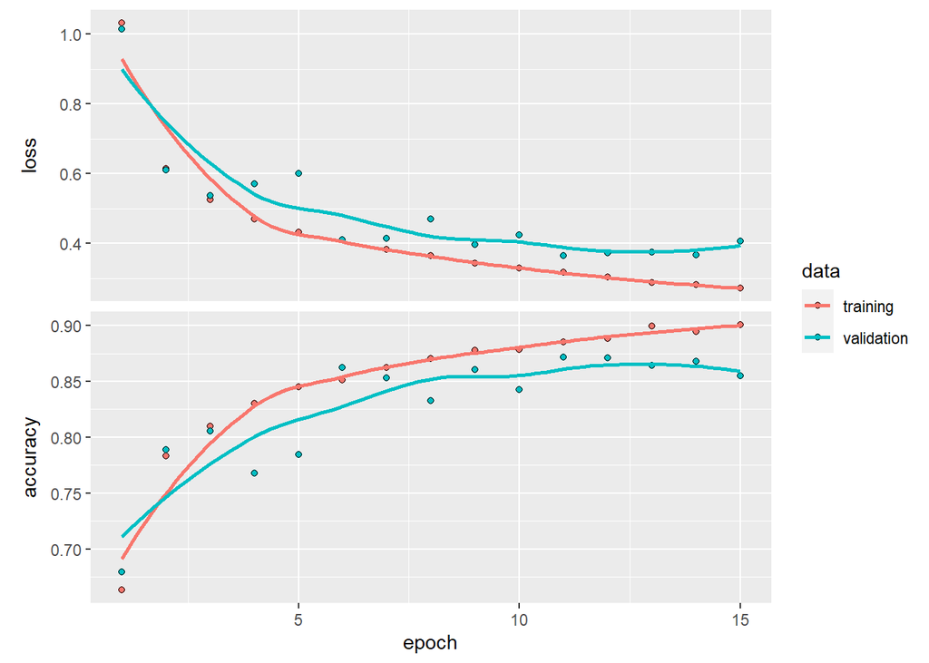

```r
# Number of parameters:
# - `layer_conv_2d` turns 28 x 28 to 26 x 26, using 9 parameters for each filter (3 x 3 weights),
# plus a bias for each filter, altogether 320 parameters
# - `max_pooling2d` takes each disjoint 2 x 2 squares and collapses them to 1, turning a 26 x 26
# "image" to a 13 x 13. No parameters are associated with this step.
# - `flatten`: turns each "pixel" in each node to one separate node: 13 x 13 x 32 = 5408
# - `dense`: fully connected layer: 5408 nodes x 16 new nodes + 16 biases = 86544
# - final fully connected layer: 16 x 10 + 10 = 170

compile(
  cnn_model_janos,
  loss = 'categorical_crossentropy',
  optimizer = optimizer_rmsprop(),
  metrics = c('accuracy')
)

# set.seed(1234)
# janosRDS_CNN <- fit(
#   cnn_model_janos, data_train_x, data_train_y,
#   epochs = 15, batch_size = 128,
#   validation_data = list(data_valid_x, data_valid_y)
# )

# saveRDS(janosRDS_CNN, file = "data/janosRDS_CNN.rds")
janosRDS_CNN <- readRDS(file = "F:/OneDrive - Central European University/Courses/Winter_Term/Data Science 2/assignment 2/DS2-neural-nets/data/janosRDS_CNN.rds")

# Save the model
# save_model_hdf5(cnn_model_janos, "data/cnn_model_janos.h5")

# Recreate the exact same model purely from the file
cnn_model_janos <- load_model_hdf5("F:/OneDrive - Central European University/Courses/Winter_Term/Data Science 2/assignment 2/DS2-neural-nets/data/cnn_model_janos.h5")

# evaluate model
model_janos_cnn_eval <- as.data.frame(evaluate(cnn_model_janos, data_valid_x, data_valid_y))

plot(janosRDS_CNN)
```

The first model is a less complex version of Janos’ model by increasing the kernel size to 5x5 squares and the pooling size to 3x3 squares. Coupled with 10 filter nodes in the convolutional layer, this model is expected to perform worse than the benchmark.

```r
### CNN Model 1 --> less complex version of Janos' model
# lower performance, but train & valid performance is streamlined

cnn_model1 <- keras_model_sequential()
cnn_model1 %>%
  layer_conv_2d(
    filters = 10, # number of nodes in this layer (could be anything?!)
    kernel_size = c(5, 5), # search across the input space in 5x5 squares rather than 1x1 squares (which are just individual pixels)
    activation = 'relu',
    input_shape = c(28, 28, 1)
  ) %>%
  layer_max_pooling_2d(pool_size = c(3, 3)) %>% # converts space by taking max value from each 3x3 squares
  layer_dropout(rate = 0.25) %>%
  # Dense layers take vectors as input (which are 1D), while the current output is a 3D tensor.
  # First, you will flatten (or unroll) the 3D output to 1D, then add one or more Dense layers on top.
  # MINIST has 10 output classes, so you use a final Dense layer with 10 outputs and a softmax activation.
  layer_flatten() %>% # increases complexity
  layer_dense(units = 10, activation = 'relu') %>% # arbitrary
  layer_dense(units = 10, activation = 'softmax') # arbitrary

summary(cnn_model1)
```

```
## Model: "sequential_7"
## ________________________________________________________________________________
## Layer (type)                        Output Shape                    Param #
## ================================================================================
## conv2d_1 (Conv2D)                   (None, 24, 24, 10)              260
## ________________________________________________________________________________
## max_pooling2d_1 (MaxPooling2D)      (None, 8, 8, 10)                0
## ________________________________________________________________________________
## dropout_5 (Dropout)                 (None, 8, 8, 10)                0
## ________________________________________________________________________________
## flatten_1 (Flatten)                 (None, 640)                     0
## ________________________________________________________________________________
## dense_20 (Dense)                    (None, 10)                      6410
## ________________________________________________________________________________
## dense_19 (Dense)                    (None, 10)                      110
## ================================================================================
## Total params: 6,780
## Trainable params: 6,780
## Non-trainable params: 0
## ________________________________________________________________________________
```

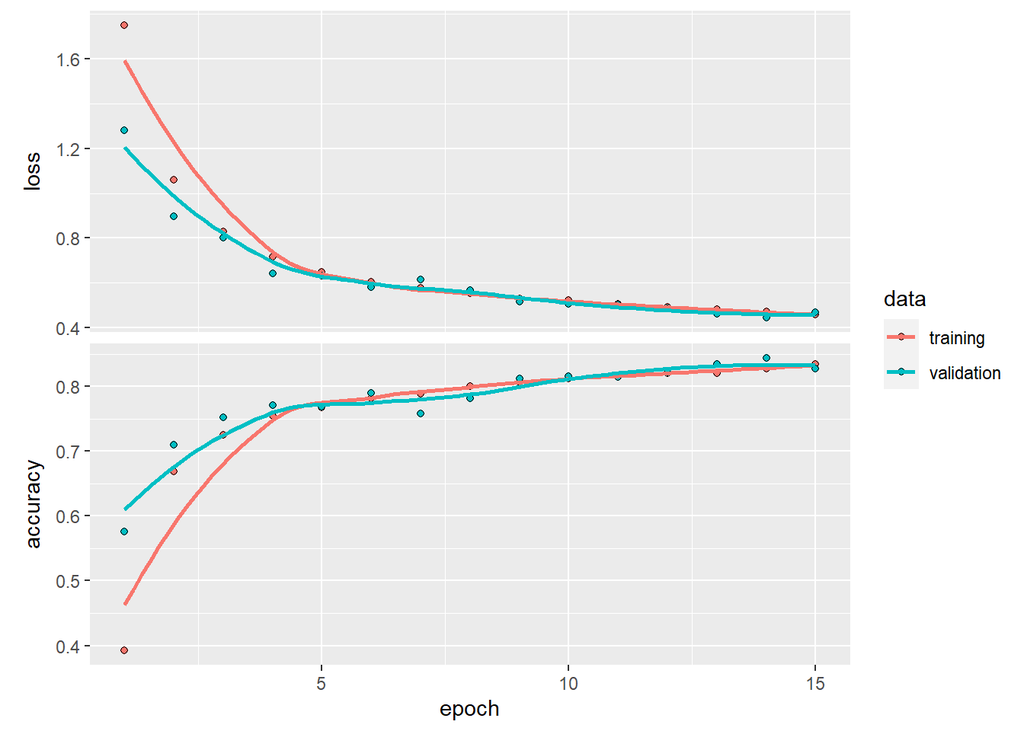

```r
compile(
  cnn_model1,
  loss = 'categorical_crossentropy',
  optimizer = optimizer_rmsprop(),
  metrics = c('accuracy')
)

# set.seed(1234)
# model1RDS_CNN <- fit(
#   cnn_model1, data_train_x, data_train_y,
#   epochs = 15, batch_size = 128,
#   validation_data = list(data_valid_x, data_valid_y)
# )

# saveRDS(model1RDS_CNN, file = "data/model1RDS_CNN.rds")
model1RDS_CNN <- readRDS(file = "F:/OneDrive - Central European University/Courses/Winter_Term/Data Science 2/assignment 2/DS2-neural-nets/data/model1RDS_CNN.rds")

# Save the model
# save_model_hdf5(cnn_model1, "data/cnn_model1.h5")

# Recreate the exact same model purely from the file
cnn_model1 <- load_model_hdf5("F:/OneDrive - Central European University/Courses/Winter_Term/Data Science 2/assignment 2/DS2-neural-nets/data/cnn_model1.h5")

# evaluate model
model1_cnn_eval <- as.data.frame(evaluate(cnn_model1, data_valid_x, data_valid_y))

plot(model1RDS_CNN)
```

The second model follows a stackoverflow example by combining the convolutional and pooling layers twice before converting back to a 1D space. This model builds upon the 5x5 kernel size and the 3x3 pooling size from the first model. It is expected to perform a slight bit better. The expectation here would be that the best performance would be achieved by first having a complex convolutional layer followed by a pooling layer (such as the case from the benchmark model) and then having the same order of layers but with much simpler parameters, such as the 5x5 kernel and the 3x3 pooling.

```r
### CNN Model 2 --> following a stackoverflow example

cnn_model2 <- keras_model_sequential()
cnn_model2 %>%
  layer_conv_2d(
    filters = 10, # number of nodes in this layer (could be anything?!)
    kernel_size = c(5, 5), # search across the input space in 5x5 squares rather than 1x1 squares (which are just individual pixels)
    activation = 'relu',
    input_shape = c(28, 28, 1)
  ) %>%
  layer_max_pooling_2d(pool_size = c(3, 3)) %>% # converts space by taking max value from each 3x3 squares
  layer_conv_2d(
    filters = 20, # number of nodes in this layer (could be anything?!)
    kernel_size = c(5, 5), # search across the input space in 5x5 squares rather than 1x1 squares (which are just individual pixels)
    activation = 'relu',
    input_shape = c(28, 28, 1)
  ) %>%
  layer_max_pooling_2d(pool_size = c(3, 3)) %>% # converts space by taking max value from each 3x3 squares
  layer_dropout(rate = 0.25) %>%
  layer_flatten() %>% # increases complexity
  layer_dense(units = 10, activation = 'relu') %>% # arbitrary
  layer_dense(units = 10, activation = 'softmax') # arbitrary

summary(cnn_model2)
```

```
## Model: "sequential_8"
## ________________________________________________________________________________
## Layer (type)                        Output Shape                    Param #
## ================================================================================
## conv2d_3 (Conv2D)                   (None, 24, 24, 10)              260
## ________________________________________________________________________________
## max_pooling2d_3 (MaxPooling2D)      (None, 8, 8, 10)                0
## ________________________________________________________________________________
## conv2d_2 (Conv2D)                   (None, 4, 4, 20)                5020
## ________________________________________________________________________________
## max_pooling2d_2 (MaxPooling2D)      (None, 1, 1, 20)                0
## ________________________________________________________________________________
## dropout_6 (Dropout)                 (None, 1, 1, 20)                0
## ________________________________________________________________________________
## flatten_2 (Flatten)                 (None, 20)                      0
## ________________________________________________________________________________
## dense_22 (Dense)                    (None, 10)                      210
## ________________________________________________________________________________
## dense_21 (Dense)                    (None, 10)                      110
## ================================================================================
## Total params: 5,600
## Trainable params: 5,600
## Non-trainable params: 0
## ________________________________________________________________________________
```

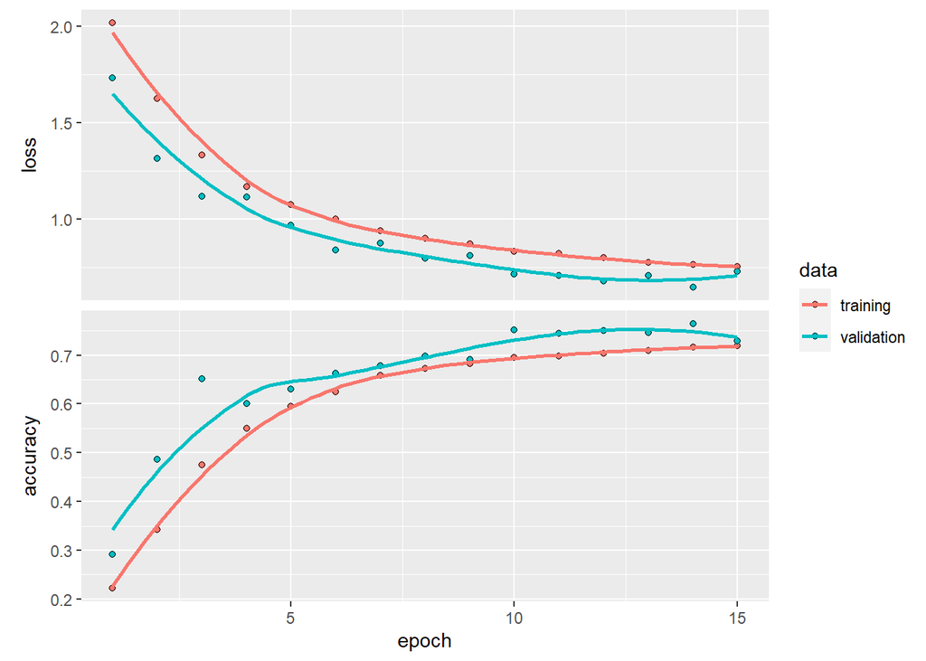

```r
compile(
  cnn_model2,
  loss = 'categorical_crossentropy',
  optimizer = optimizer_rmsprop(),
  metrics = c('accuracy')
)

# set.seed(1234)
# model2RDS_CNN <- fit(
#   cnn_model2, data_train_x, data_train_y,
#   epochs = 15, batch_size = 128,
#   validation_data = list(data_valid_x, data_valid_y)
# )

# saveRDS(model2RDS_CNN, file = "data/model2RDS_CNN.rds")
model2RDS_CNN <- readRDS(file = "F:/OneDrive - Central European University/Courses/Winter_Term/Data Science 2/assignment 2/DS2-neural-nets/data/model2RDS_CNN.rds")

# Save the model
# save_model_hdf5(cnn_model2, "data/cnn_model2.h5")

# Recreate the exact same model purely from the file
cnn_model2 <- load_model_hdf5("F:/OneDrive - Central European University/Courses/Winter_Term/Data Science 2/assignment 2/DS2-neural-nets/data/cnn_model2.h5")

# evaluate model
model2_cnn_eval <- as.data.frame(evaluate(cnn_model2, data_valid_x, data_valid_y))

plot(model2RDS_CNN)
```

Model 3 increase the complexity by adding more filter nodes in the convolutional layers and by decreasing both the kernel and pooling sizes. It is expected to perform better than the 1st and 2nd CNN models.

```r
### CNN Model 3 --> following a stackoverflow example

cnn_model3 <- keras_model_sequential()
cnn_model3 %>%
  layer_conv_2d(filters = 32, kernel_size = c(3,3), activation = "relu",
                input_shape = c(28,28,1)) %>%
  layer_max_pooling_2d(pool_size = c(2,2)) %>%
  layer_conv_2d(filters = 64, kernel_size = c(3,3), activation = "relu") %>%
  layer_max_pooling_2d(pool_size = c(2,2)) %>%
  layer_conv_2d(filters = 64, kernel_size = c(3,3), activation = "relu") %>%
  layer_dropout(rate = 0.25) %>%
  layer_flatten() %>% # increases complexity
  layer_dense(units = 10, activation = 'relu') %>% # arbitrary
  layer_dense(units = 10, activation = 'softmax') # arbitrary

summary(cnn_model3)
```

```
## Model: "sequential_9"
## ________________________________________________________________________________
## Layer (type)                        Output Shape                    Param #
## ================================================================================
## conv2d_6 (Conv2D)                   (None, 26, 26, 32)              320
## ________________________________________________________________________________
## max_pooling2d_5 (MaxPooling2D)      (None, 13, 13, 32)              0
## ________________________________________________________________________________
## conv2d_5 (Conv2D)                   (None, 11, 11, 64)              18496
## ________________________________________________________________________________
## max_pooling2d_4 (MaxPooling2D)      (None, 5, 5, 64)                0
## ________________________________________________________________________________
## conv2d_4 (Conv2D)                   (None, 3, 3, 64)                36928
## ________________________________________________________________________________
## dropout_7 (Dropout)                 (None, 3, 3, 64)                0
## ________________________________________________________________________________
## flatten_3 (Flatten)                 (None, 576)                     0
## ________________________________________________________________________________
## dense_24 (Dense)                    (None, 10)                      5770
## ________________________________________________________________________________
## dense_23 (Dense)                    (None, 10)                      110
## ================================================================================
## Total params: 61,624
## Trainable params: 61,624
## Non-trainable params: 0
## ________________________________________________________________________________
```